# Coding Outreach Group Summer Workshop - Data Wrangling in R

Content creator: **Ginny Ulichney

Content editor: **Billy Mitchell

2022-06-06

## 0.1 Introduction

[video not shown]

# 1 Section 1: Setting up the data

[video not shown]

## 1.1 Workshop Setup

I’m first going to load the couple of packages that we will need for this workshop. I’ve included a little bit of information about each of their uses in a comment below. Running the code chunk below will load the desired packages if you have already installed them, and the nice thing is, it will also automatically install any needed packages if you have not yet done so. Basically, this is possible through creating an object containing the names of the desired packages (“wrangling_packages”), creating an object containing the names of your existing packages (“packages”), and using a function to install any package names that are listed among the desired packages, but not among existing packages.

```r
wrangling_packages <- c("data.table", "effects", "lme4", "lubridate", "modelsummary",
                        "psych", "qdap", "reshape", "rJava", "rlang", "skimr",
                        "syuzhet", "tidytext", "tidyverse", "utils", "yaml")

##brief explanation of packages##
#tidyverse is for wrangling and contains ggplot2, tibble, purrr, dplyr, tidyr, stringr, readr, and forcats
#data.table is for reading large data objects
#skimr and psych are for basic statistics
#rlang and rershape are for basic wrangling
#utils, modelsummary, and yaml are for R notebook functionality
#lubridate is for updating date/time stamps
#qdap, rJava, syuzhet, and tidytext are for text analysis and cleaning
#lme4 is for linear regression exercise

packages <- rownames(installed.packages())
p_to_install <- wrangling_packages[!(wrangling_packages %in% packages)]

if(length(p_to_install) > 0){
  install.packages(p_to_install)
}

lapply(wrangling_packages, library, character.only = TRUE)
```

[output not shown]

[output cut: 107 more lines]

NOTE: If you receive an error stating: `error: JAVA_HOME cannot be determined from the Registry`, try [this troubleshooting page to resolve the issue](https://www.r-statistics.com/2012/08/how-to-load-the-rjava-package-after-the-error-java_home-cannot-be-determined-from-the-registry/).

Now let’s clean our environment of the variables we won’t need

```r
rm(p_to_install, packages, wrangling_packages)
```

We’re next going to specify the working directory to wherever you have this workshop stored locally.

```r
#check current working directory
getwd()

#change the directory to where you have the COG2022_DataWranglinginR.csv saved
wd <- "YOUR/PATH/HERE"
setwd(wd)

#we won't be using the variable wd any longer
rm(wd)
```

## 1.2 About the data

For this workshop, we will be using publicly-available New York Times Cooking comment data (found via Kaggle, which is a great source for test datasets if you’re interested). The data was collected via New York Times’s API (source below). This is the sort of data you might be using if you use web-scraped or publiclly-available social media data in your work (think Tweets, comments, online reviews), and there are all sorts of things you can do with data like this especially since there tend to be so many observations and they are completely naturalistic. * [Kaggle source](https://www.kaggle.com/datasets/michaelruddy/new-york-times-recipe-comments) * [New York Times API](https://developer.nytimes.com)

## 1.3 Import raw data

We’re first going to import the New York Times Cooking comment data as a dataframe. There are a few ways to do this that we’ll go through. You can use the “read.csv” function from the `utils` package, which is likely the most common way to load .csv data. However, You can also use the `fread` function from the `data.table` package, which is much better for datasets of this size, as we’ll see (thank you Billy for introducing me to this one)!

Note that we first list the package that it’s from followed by two colons and then the function. This is to let R know where to find the function. This usually isn’t necessary, but doing this will allow you to call a function without necessarily loading it into our environment with `library()` or, as in our case, resolve issues between packages when two packages have a similarly named function. It just tells R which package we want R to pull *Function X* from.

Also note that the dataframe starts as a zipped file. This is because the raw data is too large to be hosted by Github. You will need to extract the file first. Usually, this is an option in your right-click menu.

```r
nyt_raw <- data.table::fread("df.csv",
                 na.strings = c('', 'NA'))
```

We’re going to save the raw data to a dataframe called “nyt_raw”, which we can access anytime we need the raw data going forward. To get a sense of our data structure, we’ll use the `head` function to show a snippet of the first few rows of the dataframe (6 rows by default). We can adjust the number of rows shown with the `n = 20` command within the head function.

```r
head(nyt_raw, n = 20) #this will show a snippet of the first 20 rows of the data file
```

| V1 | commentID | status | commentSequence | userID | userDisplayName | userLocation | userTitle | userURL | picURL | commentTitle | commentBody | createDate | updateDate | approveDate | recommendations | replyCount | replies | editorsSelection | parentID | parentUserDisplayName | depth | commentType | trusted | recommendedFlag | permID | isAnonymous | recipe_id | recipe_name |
| --- | --- | --- | --- | --- | --- | --- | --- | --- | --- | --- | --- | --- | --- | --- | --- | --- | --- | --- | --- | --- | --- | --- | --- | --- | --- | --- | --- | --- |
| 0 | 20158342 | approved | 20158342 | 1570140 | Christa |  | NA | NA | NA |  | Not worth the effort--now I know why oxtails are on clearance every week. The meat was extremely fatty & difficult to debone. The article will tell you although the recipe does not that this is besr s… | 1508886192 | 1587093112 | 1476651152 | 1 | 0 | [] | FALSE | NA | NA | 1 | comment | 0 | 0 | 20158342 | FALSE | 1015646 | shredded oxtail salad with mustard and shallot |
| 0 | 110917145 | approved | 110917145 | 87444971 | Lindsey | NA | NA | NA | NA |  | This is the biscotti recipe I've been searching for! Anise biscotti at many Italian bakeries are more like Anise ""toast"" - super light, very crispy, and must be dunked to be enjoyed. These are dense… | 1609889919 | 1609890351 | 1609890351 | 0 | 0 | [] | FALSE | NA | NA | 1 | comment | 0 | 0 | 110917145 | FALSE | 1012940 | aunt gens biscotti |
| 1 | 104240855 | approved | 104240855 | 68602151 | VFR Marc | NA | NA | NA | NA |  | These biscotti are too dense. Part of the enjoyment is to dunk them (espresso, tea, anisette, etc.) and they don't absorb the liquid. | 1576802688 | 1612210806 | 1576803101 | 1 | 0 | [] | FALSE | NA | NA | 1 | comment | 0 | 0 | 104240855 | FALSE | 1012940 | aunt gens biscotti |
| 0 | 16837960 | approved | 16837960 | 30298351 | Joanne |  | NA | NA | NA |  | Easy to make, very tasty. | 1509378566 | 1534880361 | 1449141249 | 1 | 0 | [] | FALSE | NA | NA | 1 | comment | 0 | 0 | 16837960 | FALSE | 1017810 | turkey dinner canapes |
| 0 | 111016114 | approved | 111016114 | 57140404 | Rachel | NA | NA | NA | NA |  | This is very good, but please note that it's tomato puree, not tomato paste. I used the latter based on an initial misread and then the quantity matched the volume of a can, so I went with it. But it … | 1610300709 | 1610303190 | 1610303190 | 0 | 0 | [] | FALSE | NA | NA | 1 | comment | 0 | 0 | 111016114 | FALSE | 1019207 | lalla mussa dal |
| 1 | 109781447 | approved | 109781447 | 70214070 | Kiran starosta | NA | NA | NA | NA |  | I loved the recipe but I donâ\200\231t think any Indian will make it this way | 1603568760 | 1603645419 | 1603645419 | 0 | 0 | [] | FALSE | NA | NA | 1 | comment | 0 | 0 | 109781447 | FALSE | 1019207 | lalla mussa dal |
| 2 | 109316251 | approved | 109316251 | 70214070 | Kiran starosta | NA | NA | NA | NA |  | It was delicious, just follow the recipe \nAfter u have cooked and tasted following the recipe exactly , then you can make changes, if u want, but try it once with the chefs way !! | 1601143302 | 1601147173 | 1601147173 | 0 | 0 | [] | FALSE | NA | NA | 1 | comment | 0 | 0 | 109316251 | FALSE | 1019207 | lalla mussa dal |
| 3 | 108867570 | approved | 108867570 | 72725031 | MameChristina | NA | NA | NA | NA |  | Made the lentils separately in instant pot-12 minutes high pressure, used 3 c water for double recipe. SautÃ©ed garlic, minced ginger, minced chilies and 1/2 diced onion in 4 tsp of oil. Once soft add… | 1598635635 | 1608773814 | 1598642710 | 1 | 0 | [] | FALSE | NA | NA | 1 | comment | 0 | 0 | 108867570 | FALSE | 1019207 | lalla mussa dal |
| 4 | 108006364 | approved | 108006364 | 64690176 | Blair Hoffman | NA | NA | NA | NA |  | Delicious. I used coconut milk instead of cream. Came out delicious! | 1594172913 | 1595877703 | 1594173823 | 1 | 0 | [] | FALSE | NA | NA | 1 | comment | 0 | 0 | 108006364 | FALSE | 1019207 | lalla mussa dal |
| 5 | 107941091 | approved | 107941091 | 57639707 | Amber | NA | NA | NA | NA |  | Best dal ever. I only had one serrano chili and substituted Thai chilis for the rest. I doubled the recipe so I could use an entire can of tomatoes. I started cooking the tomato mixture right after th… | 1593806261 | 1593867633 | 1593867633 | 0 | 0 | [] | FALSE | NA | NA | 1 | comment | 0 | 0 | 107941091 | FALSE | 1019207 | lalla mussa dal |

[output cut: 10 more lines]

The data I imported here is the raw data file downloaded straight from the Kaggle page. As we can see from the snippet above, it’s not very well-organized, which is where this workshop should come in handy! We’ll walk through organization steps now.

## 1.4 Data Organization

Based on the New York Times Cooking API and the data source on Kaggle, it looks like the columns in our dataset are organized as follows. Italicized column names are those we will be examining today:

- V1: the index of the comment within a specific recipe
- *commentID: the comment’s unique identifying number*
- status: whether or not NYT has approved the comment
- commentSequence: the comment’s sequence
- *userID: the ID number of the user who wrote the comment*
- userDisplayName: first name or handle selected by user who wrote the comment
- userLocation: location of the user (locked)
- userTitle: the user’s title, if they have one (e.g., “food critic”; locked)
- userURL: the user’s NYT cooking profile URL (locked)
- picURL: the URL of the photo included in the comment (locked)
- commentTitle: the “subject line”/title of the user’s comment
- *commentBody: the comment text*
- *createDate: unix time stamp of comment creation date*
- updateDate: unix time stamp of any comment updates
- approveDate: unix time stamp of comment approval date
- *recommendations: number of other users who liked a specific comment*
- *replyCount: number of replies to a particular comment*
- replies: replies written to each specific comment
- editorsSelection: whether or not the comment has been selected as an “Editor’s Selection” comment
- parentID: if reply, comment ID for the original comment (locked)
- parentUserDisplay: if reply, user ID for original comment (locked)
- depth: comment depth
- commentType: original comment vs. reporter reply
- trusted: whether or not the comment is trusted
- recommendedFlag: whether or not the comment has a recommended flag
- permID: permanent comment ID -
- isAnonymous: whether or not the comment is anonymous
- *recipe_id: ID number for the recipe commented on*
- *recipe_name: name of the recipe commented on*

## 1.5 Examining raw data structure

We will now explore our dataset using a couple of Base R commands.

```r
#copying the data to a new object so that we can retain the raw data separately
nyt <- nyt_raw
```

First, we’re going to get a sense of the data using a couple of basic Base R commands. This will tell us about the structure of the dataset, or the way in which R categorizes each of the variables (i.e., numeric, character, etc.). This is important to keep in mind because R will treat variables differently based upon how they are structured.

```r
str(nyt) #shows us what kinds of variables we have
```

```
## Classes 'data.table' and 'data.frame':   389963 obs. of  29 variables:
##  $ V1                   : int  0 0 1 0 0 1 2 3 4 5 ...
##  $ commentID            : num  2.02e+07 1.11e+08 1.04e+08 1.68e+07 1.11e+08 ...
##  $ status               : chr  "approved" "approved" "approved" "approved" ...
##  $ commentSequence      : num  2.02e+07 1.11e+08 1.04e+08 1.68e+07 1.11e+08 ...
##  $ userID               : num  1570140 87444971 68602151 30298351 57140404 ...
##  $ userDisplayName      : chr  "Christa" "Lindsey" "VFR Marc" "Joanne" ...
##  $ userLocation         : chr  "<br/>" NA NA "<br/>" ...
##  $ userTitle            : chr  NA NA NA NA ...
##  $ userURL              : logi  NA NA NA NA NA NA ...
##  $ picURL               : chr  NA NA NA NA ...
##  $ commentTitle         : chr  "<br\\//>" "<br\\//>" "<br\\//>" "<br\\//>" ...
##  $ commentBody          : chr  "Not worth the effort--now I know why oxtails are on clearance every week. The meat was extremely fatty & diffic"| __truncated__ "This is the biscotti recipe I've been searching for! Anise biscotti at many Italian bakeries are more like Anis"| __truncated__ "These b…
##  $ createDate           : num  1.51e+09 1.61e+09 1.58e+09 1.51e+09 1.61e+09 ...
##  $ updateDate           : num  1.59e+09 1.61e+09 1.61e+09 1.53e+09 1.61e+09 ...
```

[output cut: 16 more lines]

Next, we’ll use the `names()` function to examine the column names of our dataframe, which essentially function as the names of our variables.

```r
names(nyt) #shows column names
```

```
##  [1] "V1"                    "commentID"             "status"
##  [4] "commentSequence"       "userID"                "userDisplayName"
##  [7] "userLocation"          "userTitle"             "userURL"
## [10] "picURL"                "commentTitle"          "commentBody"
## [13] "createDate"            "updateDate"            "approveDate"
## [16] "recommendations"       "replyCount"            "replies"
## [19] "editorsSelection"      "parentID"              "parentUserDisplayName"
## [22] "depth"                 "commentType"           "trusted"
## [25] "recommendedFlag"       "permID"                "isAnonymous"
## [28] "recipe_id"             "recipe_name"
```

We can look at how frequently each unique value appeared within any given column using the `tables()` function and specifying the column as the object of the function. Let’s look at how many replies each entry got.

```r
table(nyt$replyCount)
```

```
##
##      0      1      2      3      4      5      6      7      8      9     10
## 346554  30085   7498   2653   1234    611    346    225    149    135     79
##     11     12     13     14     15     16     17     18     19     20     21
##     60     57     36     33     24     21     19     15     13      9      6
##     22     23     24     25     26     27     28     29     30     32     33
##     13      5     11      7      6      6      3      3      6      5      5
##     34     35     36     37     38     39     40     41     42     44     46
##      3      1      2      2      2      1      2      1      1      1      1
##     49     50     53     55     57     59     61     63     67     99    114
##      1      2      1      1      1      3      1      1      1      1      1
```

We can also use it with qualitative variables like recipe names.

```r
table(nyt$recipe_name)
```

```
##
##                                                                          1 2 3 4 cake
##                                                                                    20
##                                                        15 minute fried herbed chicken
##                                                                                    76
##                                         3 bean good luck salad with cumin vinaigrette
##                                                                                    28
##                                                                5 ingredient apple pie
##                                                                                    13
##                                                                       5 minute hummus
##                                                                                   280
##                                                                              7up cake
##                                                                                   107
##                                                                     a beer and a shot
##                                                                                    13
##                                                          a big pot of simmered pintos
##                                                                                    37
##                                            a meal in a bowl salmon shiitakes and peas
##                                                                                     4
##                                              a mess of pork chops with dijon dressing
##                                                                                    10
##                                                             a perfect hard boiled egg
##                                                                                    41
##                                                                     a plain pizza pie
##                                                                                    18
##                                                               a potato dish for julia
##                                                                                     5
##                                                               a spice cookie to share
##                                                                                    16
##                                                   a very updated vegetable chartreuse
##                                                                                    16
##                                                                       abalone ceviche
##                                                                                     1
##                                                     abc kitchen rye whiskey manhattan
##                                                                                     1
##                                               abgoosht persian lamb and chickpea stew
##                                                                                     5
##                                                                       absinthe frappe
##                                                                                     1
##                                                                  abstract art cookies
```

[output cut: 16848 more lines]

```
##                                                                                    14
##                                                                     zuni cafe chicken
##                                                                                    88
##                                                                   zuni cafes focaccia
##                                                                                    15
##                                                                  zuni cafes hamburger
##                                                                                     8
##                                                          zuni cafes red onion pickles
##                                                                                    37
##                                                          zuni cafes small batch aioli
##                                                                                    19
##                                                           zuni cafes zucchini pickles
##                                                                                    14
##                                                                     zuppa arcidossana
##                                                                                     4
```

. . . and we can clean this table up a little bit by converting it into a dataframe

```r
data.frame(table(nyt$recipe_name))
```

| Var1 | Freq |
| --- | --- |
| 1 2 3 4 cake | 20 |
| 15 minute fried herbed chicken | 76 |
| 3 bean good luck salad with cumin vinaigrette | 28 |
| 5 ingredient apple pie | 13 |
| 5 minute hummus | 280 |
| 7up cake | 107 |
| a beer and a shot | 13 |
| a big pot of simmered pintos | 37 |
| a meal in a bowl salmon shiitakes and peas | 4 |
| a mess of pork chops with dijon dressing | 10 |

[output cut: 8441 more lines]

Next, we can get descriptive statistics for individual numeric variables.

```r
mean(nyt$replyCount)
```

```
## [1] 0.1932876
```

```r
sd(nyt$replyCount)
```

```
## [1] 0.9504739
```

We can also use visualizations to understand our variables of interest.

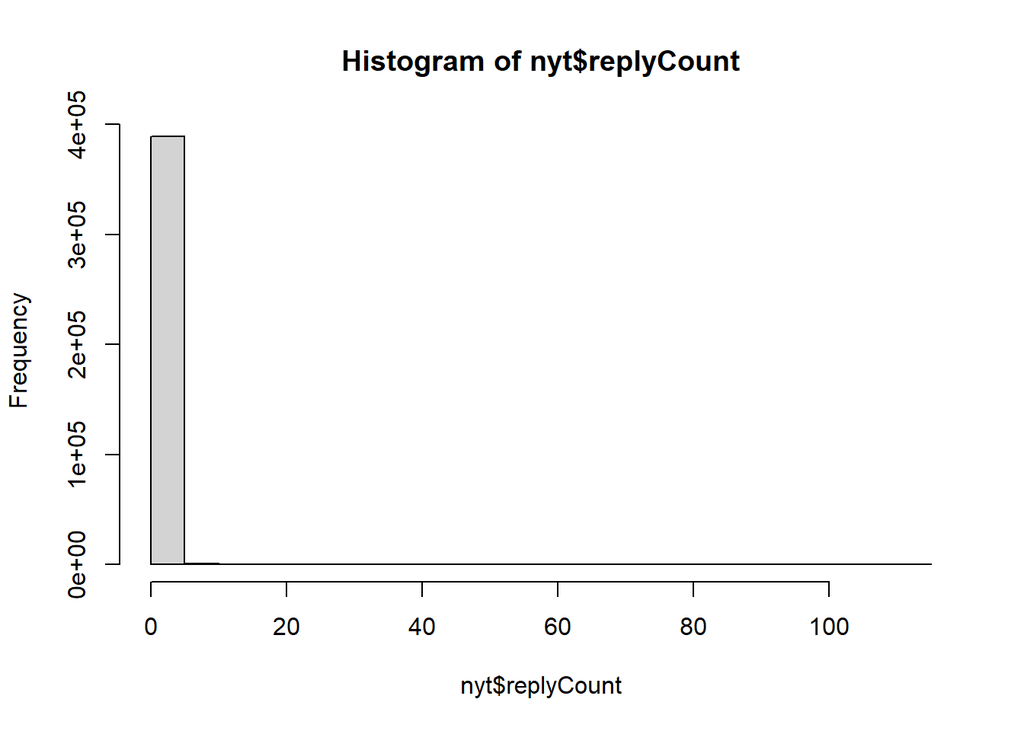

```r
hist(nyt$replyCount)
```

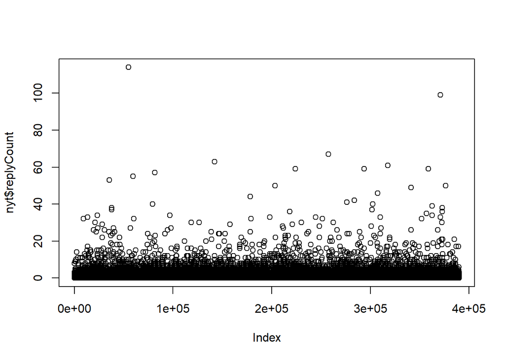

```r
plot(nyt$replyCount)
```

Checking our data for quality assurance could clearly become a lengthy process depending on the number of variables you’re looking at! Here are a few commands to make data exploration more concise:

NOTE: The `datasummary_skim` function output may appear empty in Markdown, but text is just white and can be seen if highlighted.

```r
#skim the entire dataframe using the skimr package
skim(nyt)
```

Data summary

| Name | nyt |
| --- | --- |
| Number of rows | 389963 |
| Number of columns | 29 |
| Key | NULL |
| _______________________ |  |
| Column type frequency: |  |
| character | 10 |
| logical | 5 |
| numeric | 14 |
| ________________________ |  |
| Group variables | None |

**Variable type: character**

| skim_variable | n_missing | complete_rate | min | max | empty | n_unique | whitespace |
| --- | --- | --- | --- | --- | --- | --- | --- |
| status | 0 | 1.00 | 8 | 8 | 0 | 1 | 0 |
| userDisplayName | 25 | 1.00 | 1 | 254 | 0 | 75693 | 0 |
| userLocation | 241963 | 0.38 | 2 | 27 | 0 | 214 | 0 |
| userTitle | 389954 | 0.00 | 6 | 46 | 0 | 7 | 0 |
| picURL | 383228 | 0.02 | 140 | 142 | 0 | 1734 | 0 |
| commentTitle | 0 | 1.00 | 7 | 7 | 0 | 1 | 0 |
| commentBody | 0 | 1.00 | 1 | 1566 | 0 | 387952 | 0 |
| replies | 0 | 1.00 | 2 | 3514 | 0 | 43390 | 0 |
| commentType | 0 | 1.00 | 7 | 13 | 0 | 2 | 0 |
| recipe_name | 0 | 1.00 | 1 | 85 | 0 | 8451 | 0 |

**Variable type: logical**

| skim_variable | n_missing | complete_rate | mean | count |
| --- | --- | --- | --- | --- |
| userURL | 389963 | 0 | NaN | : |
| editorsSelection | 0 | 1 | 0 | FAL: 389962, TRU: 1 |
| parentID | 389963 | 0 | NaN | : |
| parentUserDisplayName | 389963 | 0 | NaN | : |
| isAnonymous | 0 | 1 | 0 | FAL: 389956, TRU: 7 |

**Variable type: numeric**

| skim_variable | n_missing | complete_rate | mean | sd | p0 | p25 | p50 | p75 | p100 | hist |
| --- | --- | --- | --- | --- | --- | --- | --- | --- | --- | --- |
| V1 | 0 | 1 | 9.857000e+01 | 152.56 | 0 | 15 | 46 | 116 | 1705 | ▇▁▁▁▁ |
| commentID | 0 | 1 | 7.341614e+07 | 41466234.79 | 13918475 | 25791077 | 103490997 | 109167340 | 113390475 | ▆▁▁▁▇ |
| commentSequence | 0 | 1 | 7.341614e+07 | 41466234.79 | 13918475 | 25791077 | 103490997 | 109167340 | 113390475 | ▆▁▁▁▇ |
| userID | 0 | 1 | 6.157924e+07 | 27249884.48 | 0 | 48022158 | 65716760 | 77622272 | 168185963 | ▃▇▇▁▁ |
| createDate | 0 | 1 | 1.563805e+09 | 39753352.22 | 1506535652 | 1517507827 | 1572921711 | 1600379839 | 1624644283 | ▇▃▃▆▆ |
| updateDate | 0 | 1 | 1.583112e+09 | 29467403.04 | 1534873477 | 1553461799 | 1590170384 | 1609358704 | 1624647142 | ▆▂▃▆▇ |
| approveDate | 0 | 1 | 1.556066e+09 | 52665810.20 | 1422032767 | 1517503355 | 1572952389 | 1600383580 | 1624644311 | ▂▂▃▅▇ |
| recommendations | 0 | 1 | 5.040000e+00 | 30.33 | 0 | 0 | 0 | 1 | 3515 | ▇▁▁▁▁ |
| replyCount | 0 | 1 | 1.900000e-01 | 0.95 | 0 | 0 | 0 | 0 | 114 | ▇▁▁▁▁ |
| depth | 0 | 1 | 1.000000e+00 | 0.00 | 1 | 1 | 1 | 1 | 1 | ▁▁▇▁▁ |
| trusted | 0 | 1 | 0.000000e+00 | 0.00 | 0 | 0 | 0 | 0 | 0 | ▁▁▇▁▁ |
| recommendedFlag | 0 | 1 | 0.000000e+00 | 0.00 | 0 | 0 | 0 | 0 | 0 | ▁▁▇▁▁ |
| permID | 0 | 1 | 7.341614e+07 | 41466234.79 | 13918475 | 25791077 | 103490997 | 109167340 | 113390475 | ▆▁▁▁▇ |
| recipe_id | 0 | 1 | 9.641468e+05 | 227262.72 | 852 | 1016103 | 1018730 | 1020415 | 1022354 | ▁▁▁▁▇ |

```r
datasummary_skim(nyt,) #this makes a nice table for R-markdown
```

Unique (#)

Missing (%)

Mean

SD

Min

Median

Max

V1

1706

0

98.6

152.6

0.0

46.0

1705.0

[figure not shown]

commentID

389738

0

73416138.1

41466234.8

13918475.0

103490997.0

113390475.0

[figure not shown]

commentSequence

389738

0

73416138.1

41466234.8

13918475.0

103490997.0

113390475.0

[figure not shown]

userID

154253

0

61579242.6

27249884.5

0.0

65716760.0

168185963.0

[figure not shown]

createDate

346960

0

1563804724.6

39753352.2

1506535652.0

1572921711.0

1624644283.0

[figure not shown]

updateDate

193817

0

1583112469.5

29467403.0

1534873477.0

1590170384.0

1624647142.0

[figure not shown]

approveDate

122759

0

1556065791.6

52665810.2

1422032767.0

1572952389.0

1624644311.0

[figure not shown]

recommendations

642

0

5.0

30.3

0.0

0.0

3515.0

[figure not shown]

replyCount

55

0

0.2

1.0

0.0

0.0

114.0

[figure not shown]

depth

1

0

1.0

0.0

1.0

1.0

1.0

trusted

1

0

0.0

0.0

0.0

0.0

0.0

recommendedFlag

1

0

0.0

0.0

0.0

0.0

0.0

permID

389738

0

73416138.1

41466234.8

13918475.0

103490997.0

113390475.0

[figure not shown]

recipe_id

8436

0

964146.8

227262.7

852.0

1018730.0

1022354.0

[figure not shown]

## 1.6 Troubleshooting

From here on out, if you have any questions on how a specific function works or is formatted, the R Studio help window will help you out. To search a function, simply write a question mark (?) followed by the function in your console.

```r
#?[FUNCTION] #use this to learn more about how a function works in the "help" panel to the right
?hist()
```

```
## starting httpd help server ... done
```

## 1.7 Check your work

I will also be using the `head()` function from the `utils` package to periodically check work at each step in the process.

```r
head(nyt, n = 10) #specify number of rows desired using "n =" (default is 6 rows)
```

| V1 | commentID | status | commentSequence | userID | userDisplayName | userLocation | userTitle | userURL | picURL | commentTitle | commentBody | createDate | updateDate | approveDate | recommendations | replyCount | replies | editorsSelection | parentID | parentUserDisplayName | depth | commentType | trusted | recommendedFlag | permID | isAnonymous | recipe_id | recipe_name |
| --- | --- | --- | --- | --- | --- | --- | --- | --- | --- | --- | --- | --- | --- | --- | --- | --- | --- | --- | --- | --- | --- | --- | --- | --- | --- | --- | --- | --- |
| 0 | 20158342 | approved | 20158342 | 1570140 | Christa |  | NA | NA | NA |  | Not worth the effort--now I know why oxtails are on clearance every week. The meat was extremely fatty & difficult to debone. The article will tell you although the recipe does not that this is besr s… | 1508886192 | 1587093112 | 1476651152 | 1 | 0 | [] | FALSE | NA | NA | 1 | comment | 0 | 0 | 20158342 | FALSE | 1015646 | shredded oxtail salad with mustard and shallot |
| 0 | 110917145 | approved | 110917145 | 87444971 | Lindsey | NA | NA | NA | NA |  | This is the biscotti recipe I've been searching for! Anise biscotti at many Italian bakeries are more like Anise ""toast"" - super light, very crispy, and must be dunked to be enjoyed. These are dense… | 1609889919 | 1609890351 | 1609890351 | 0 | 0 | [] | FALSE | NA | NA | 1 | comment | 0 | 0 | 110917145 | FALSE | 1012940 | aunt gens biscotti |
| 1 | 104240855 | approved | 104240855 | 68602151 | VFR Marc | NA | NA | NA | NA |  | These biscotti are too dense. Part of the enjoyment is to dunk them (espresso, tea, anisette, etc.) and they don't absorb the liquid. | 1576802688 | 1612210806 | 1576803101 | 1 | 0 | [] | FALSE | NA | NA | 1 | comment | 0 | 0 | 104240855 | FALSE | 1012940 | aunt gens biscotti |
| 0 | 16837960 | approved | 16837960 | 30298351 | Joanne |  | NA | NA | NA |  | Easy to make, very tasty. | 1509378566 | 1534880361 | 1449141249 | 1 | 0 | [] | FALSE | NA | NA | 1 | comment | 0 | 0 | 16837960 | FALSE | 1017810 | turkey dinner canapes |
| 0 | 111016114 | approved | 111016114 | 57140404 | Rachel | NA | NA | NA | NA |  | This is very good, but please note that it's tomato puree, not tomato paste. I used the latter based on an initial misread and then the quantity matched the volume of a can, so I went with it. But it … | 1610300709 | 1610303190 | 1610303190 | 0 | 0 | [] | FALSE | NA | NA | 1 | comment | 0 | 0 | 111016114 | FALSE | 1019207 | lalla mussa dal |
| 1 | 109781447 | approved | 109781447 | 70214070 | Kiran starosta | NA | NA | NA | NA |  | I loved the recipe but I donâ\200\231t think any Indian will make it this way | 1603568760 | 1603645419 | 1603645419 | 0 | 0 | [] | FALSE | NA | NA | 1 | comment | 0 | 0 | 109781447 | FALSE | 1019207 | lalla mussa dal |
| 2 | 109316251 | approved | 109316251 | 70214070 | Kiran starosta | NA | NA | NA | NA |  | It was delicious, just follow the recipe \nAfter u have cooked and tasted following the recipe exactly , then you can make changes, if u want, but try it once with the chefs way !! | 1601143302 | 1601147173 | 1601147173 | 0 | 0 | [] | FALSE | NA | NA | 1 | comment | 0 | 0 | 109316251 | FALSE | 1019207 | lalla mussa dal |
| 3 | 108867570 | approved | 108867570 | 72725031 | MameChristina | NA | NA | NA | NA |  | Made the lentils separately in instant pot-12 minutes high pressure, used 3 c water for double recipe. SautÃ©ed garlic, minced ginger, minced chilies and 1/2 diced onion in 4 tsp of oil. Once soft add… | 1598635635 | 1608773814 | 1598642710 | 1 | 0 | [] | FALSE | NA | NA | 1 | comment | 0 | 0 | 108867570 | FALSE | 1019207 | lalla mussa dal |
| 4 | 108006364 | approved | 108006364 | 64690176 | Blair Hoffman | NA | NA | NA | NA |  | Delicious. I used coconut milk instead of cream. Came out delicious! | 1594172913 | 1595877703 | 1594173823 | 1 | 0 | [] | FALSE | NA | NA | 1 | comment | 0 | 0 | 108006364 | FALSE | 1019207 | lalla mussa dal |
| 5 | 107941091 | approved | 107941091 | 57639707 | Amber | NA | NA | NA | NA |  | Best dal ever. I only had one serrano chili and substituted Thai chilis for the rest. I doubled the recipe so I could use an entire can of tomatoes. I started cooking the tomato mixture right after th… | 1593806261 | 1593867633 | 1593867633 | 0 | 0 | [] | FALSE | NA | NA | 1 | comment | 0 | 0 | 107941091 | FALSE | 1019207 | lalla mussa dal |

## 1.8 Renaming columns

It’s clear that the raw data we downloaded is pretty messy, and is going to require some wrangling on our end. First off, some of our columns are not named very descriptively nor consistently. There are generally two naming conventions used in R (and data science more generally): “columnName” or “column_name”. We have a few columns that are each named using different conventions, which adds to the messiness. We’re going to give our columns more consistent and descriptive names using the `rename()` function from the `dplyr` package.

```r
names(nyt)
```

```
##  [1] "V1"                    "commentID"             "status"
##  [4] "commentSequence"       "userID"                "userDisplayName"
##  [7] "userLocation"          "userTitle"             "userURL"
## [10] "picURL"                "commentTitle"          "commentBody"
## [13] "createDate"            "updateDate"            "approveDate"
## [16] "recommendations"       "replyCount"            "replies"
## [19] "editorsSelection"      "parentID"              "parentUserDisplayName"
## [22] "depth"                 "commentType"           "trusted"
## [25] "recommendedFlag"       "permID"                "isAnonymous"
## [28] "recipe_id"             "recipe_name"
```

```r
# Rename individual columns using consistent naming conventions with rest of df
nyt <- dplyr::rename(nyt,
                     c('recipeName' = 'recipe_name',
                       'recipeID' = 'recipe_id'))

# Or rename columns in a batch!
nyt <- rename_with(nyt, ~ (gsub("user",
                                "author",
                                .x,
                                fixed = TRUE)))

#check work
head(nyt, n = 10)
```

| V1 | commentID | status | commentSequence | authorID | authorDisplayName | authorLocation | authorTitle | authorURL | picURL | commentTitle | commentBody | createDate | updateDate | approveDate | recommendations | replyCount | replies | editorsSelection | parentID | parentUserDisplayName | depth | commentType | trusted | recommendedFlag | permID | isAnonymous | recipeID | recipeName |
| --- | --- | --- | --- | --- | --- | --- | --- | --- | --- | --- | --- | --- | --- | --- | --- | --- | --- | --- | --- | --- | --- | --- | --- | --- | --- | --- | --- | --- |
| 0 | 20158342 | approved | 20158342 | 1570140 | Christa |  | NA | NA | NA |  | Not worth the effort--now I know why oxtails are on clearance every week. The meat was extremely fatty & difficult to debone. The article will tell you although the recipe does not that this is besr s… | 1508886192 | 1587093112 | 1476651152 | 1 | 0 | [] | FALSE | NA | NA | 1 | comment | 0 | 0 | 20158342 | FALSE | 1015646 | shredded oxtail salad with mustard and shallot |
| 0 | 110917145 | approved | 110917145 | 87444971 | Lindsey | NA | NA | NA | NA |  | This is the biscotti recipe I've been searching for! Anise biscotti at many Italian bakeries are more like Anise ""toast"" - super light, very crispy, and must be dunked to be enjoyed. These are dense… | 1609889919 | 1609890351 | 1609890351 | 0 | 0 | [] | FALSE | NA | NA | 1 | comment | 0 | 0 | 110917145 | FALSE | 1012940 | aunt gens biscotti |
| 1 | 104240855 | approved | 104240855 | 68602151 | VFR Marc | NA | NA | NA | NA |  | These biscotti are too dense. Part of the enjoyment is to dunk them (espresso, tea, anisette, etc.) and they don't absorb the liquid. | 1576802688 | 1612210806 | 1576803101 | 1 | 0 | [] | FALSE | NA | NA | 1 | comment | 0 | 0 | 104240855 | FALSE | 1012940 | aunt gens biscotti |
| 0 | 16837960 | approved | 16837960 | 30298351 | Joanne |  | NA | NA | NA |  | Easy to make, very tasty. | 1509378566 | 1534880361 | 1449141249 | 1 | 0 | [] | FALSE | NA | NA | 1 | comment | 0 | 0 | 16837960 | FALSE | 1017810 | turkey dinner canapes |
| 0 | 111016114 | approved | 111016114 | 57140404 | Rachel | NA | NA | NA | NA |  | This is very good, but please note that it's tomato puree, not tomato paste. I used the latter based on an initial misread and then the quantity matched the volume of a can, so I went with it. But it … | 1610300709 | 1610303190 | 1610303190 | 0 | 0 | [] | FALSE | NA | NA | 1 | comment | 0 | 0 | 111016114 | FALSE | 1019207 | lalla mussa dal |
| 1 | 109781447 | approved | 109781447 | 70214070 | Kiran starosta | NA | NA | NA | NA |  | I loved the recipe but I donâ\200\231t think any Indian will make it this way | 1603568760 | 1603645419 | 1603645419 | 0 | 0 | [] | FALSE | NA | NA | 1 | comment | 0 | 0 | 109781447 | FALSE | 1019207 | lalla mussa dal |
| 2 | 109316251 | approved | 109316251 | 70214070 | Kiran starosta | NA | NA | NA | NA |  | It was delicious, just follow the recipe \nAfter u have cooked and tasted following the recipe exactly , then you can make changes, if u want, but try it once with the chefs way !! | 1601143302 | 1601147173 | 1601147173 | 0 | 0 | [] | FALSE | NA | NA | 1 | comment | 0 | 0 | 109316251 | FALSE | 1019207 | lalla mussa dal |
| 3 | 108867570 | approved | 108867570 | 72725031 | MameChristina | NA | NA | NA | NA |  | Made the lentils separately in instant pot-12 minutes high pressure, used 3 c water for double recipe. SautÃ©ed garlic, minced ginger, minced chilies and 1/2 diced onion in 4 tsp of oil. Once soft add… | 1598635635 | 1608773814 | 1598642710 | 1 | 0 | [] | FALSE | NA | NA | 1 | comment | 0 | 0 | 108867570 | FALSE | 1019207 | lalla mussa dal |
| 4 | 108006364 | approved | 108006364 | 64690176 | Blair Hoffman | NA | NA | NA | NA |  | Delicious. I used coconut milk instead of cream. Came out delicious! | 1594172913 | 1595877703 | 1594173823 | 1 | 0 | [] | FALSE | NA | NA | 1 | comment | 0 | 0 | 108006364 | FALSE | 1019207 | lalla mussa dal |
| 5 | 107941091 | approved | 107941091 | 57639707 | Amber | NA | NA | NA | NA |  | Best dal ever. I only had one serrano chili and substituted Thai chilis for the rest. I doubled the recipe so I could use an entire can of tomatoes. I started cooking the tomato mixture right after th… | 1593806261 | 1593867633 | 1593867633 | 0 | 0 | [] | FALSE | NA | NA | 1 | comment | 0 | 0 | 107941091 | FALSE | 1019207 | lalla mussa dal |

## 1.9 Selecting columns and filtering rows

It looks like there are a lot of extra columns we aren’t interested in in this data. We can access the column names directly using the `names` function (above), and then use `dplyr`’s select() function to choose the columns we would like to keep. I usually specify that I want to use `dplyr`’s `select()` function instead of any select function from another package (for example, there’s also one in the `psych` package that sometimes conflicts with `dplyr`) by writing the package name and 2 colons before the function (`dplyr::select()`).

We can also clean data up to use only rows that we are interested in using `filter()` or `subset()` functions. I’m first going to select all rows with “approved” comments by using the `filter()` function. It’s worth noting that one can filter for rows containing values in a column that are equal to (`==`) or unequal to (`!=`) a specific reference value. You can do the same for numeric variables (as we’ll see later on in the “arrange and sort” section), or could also select reference values that are greater than (`>`)/greater than or equal to (`>=`), or less than (`<`)/less than or equal to (`<=`) a specific reference value.

```r
#select by row: this will allow us to keep only comments that have been "approved"
nyt <- filter(nyt, status == "approved") #find status = approved
nrow(nyt) #looks like we didn't lose any rows, so they all were "approved"!
```

```
## [1] 389963
```

```r
#select by column: this will allow us to choose only columns we'll need for the rest of our analyses
names(nyt)
```

```
##  [1] "V1"                    "commentID"             "status"
##  [4] "commentSequence"       "authorID"              "authorDisplayName"
##  [7] "authorLocation"        "authorTitle"           "authorURL"
## [10] "picURL"                "commentTitle"          "commentBody"
## [13] "createDate"            "updateDate"            "approveDate"
## [16] "recommendations"       "replyCount"            "replies"
## [19] "editorsSelection"      "parentID"              "parentUserDisplayName"
## [22] "depth"                 "commentType"           "trusted"
## [25] "recommendedFlag"       "permID"                "isAnonymous"
## [28] "recipeID"              "recipeName"
```

```r
nyt <- dplyr::select(nyt, c('commentID', 'commentBody', 'createDate',
                            'recommendations', 'recipeName', 'recipeID',
                            'replyCount', 'authorID', 'status'))

#remove an additional column
nyt <- dplyr::select(nyt, -c('status'))

#just for instructional purposes-- select columns with with certain titles using "matches" and "starts_with"
nyt_recipes <- dplyr::select(nyt, matches('recipe') | matches('comment'))
nyt_recipes <- dplyr::select(nyt, starts_with('recipe'))
nyt_IDs <- dplyr::select(nyt, ends_with('ID'))

#you can also use "select" to rearrange columns into a desired order:
nyt <- dplyr::select(nyt, c("recipeName", "recipeID"), everything())

head(nyt, n = 10)
```

| recipeName | recipeID | commentID | commentBody | createDate | recommendations | replyCount | authorID |
| --- | --- | --- | --- | --- | --- | --- | --- |
| shredded oxtail salad with mustard and shallot | 1015646 | 20158342 | Not worth the effort--now I know why oxtails are on clearance every week. The meat was extremely fatty & difficult to debone. The article will tell you although the recipe does not that this is besr s… | 1508886192 | 1 | 0 | 1570140 |
| aunt gens biscotti | 1012940 | 110917145 | This is the biscotti recipe I've been searching for! Anise biscotti at many Italian bakeries are more like Anise ""toast"" - super light, very crispy, and must be dunked to be enjoyed. These are dense… | 1609889919 | 0 | 0 | 87444971 |
| aunt gens biscotti | 1012940 | 104240855 | These biscotti are too dense. Part of the enjoyment is to dunk them (espresso, tea, anisette, etc.) and they don't absorb the liquid. | 1576802688 | 1 | 0 | 68602151 |
| turkey dinner canapes | 1017810 | 16837960 | Easy to make, very tasty. | 1509378566 | 1 | 0 | 30298351 |
| lalla mussa dal | 1019207 | 111016114 | This is very good, but please note that it's tomato puree, not tomato paste. I used the latter based on an initial misread and then the quantity matched the volume of a can, so I went with it. But it … | 1610300709 | 0 | 0 | 57140404 |
| lalla mussa dal | 1019207 | 109781447 | I loved the recipe but I donâ\200\231t think any Indian will make it this way | 1603568760 | 0 | 0 | 70214070 |
| lalla mussa dal | 1019207 | 109316251 | It was delicious, just follow the recipe \nAfter u have cooked and tasted following the recipe exactly , then you can make changes, if u want, but try it once with the chefs way !! | 1601143302 | 0 | 0 | 70214070 |
| lalla mussa dal | 1019207 | 108867570 | Made the lentils separately in instant pot-12 minutes high pressure, used 3 c water for double recipe. SautÃ©ed garlic, minced ginger, minced chilies and 1/2 diced onion in 4 tsp of oil. Once soft add… | 1598635635 | 1 | 0 | 72725031 |
| lalla mussa dal | 1019207 | 108006364 | Delicious. I used coconut milk instead of cream. Came out delicious! | 1594172913 | 1 | 0 | 64690176 |
| lalla mussa dal | 1019207 | 107941091 | Best dal ever. I only had one serrano chili and substituted Thai chilis for the rest. I doubled the recipe so I could use an entire can of tomatoes. I started cooking the tomato mixture right after th… | 1593806261 | 0 | 0 | 57639707 |

## 1.10 Using piping to make data wrangling more concise

```r
nyt_concise <- nyt_raw

nyt_concise <- nyt_concise %>%
               filter(status == "approved") %>%
               dplyr::select(matches('recipe') |
                            matches('commentID') |
                            matches('commentBody') |
                            matches('recommendations') |
                            matches('createDate') |
                            matches('replyCount')) %>%
               dplyr::rename(c('recipeName' = 'recipe_name',
                               'recipeID' = 'recipe_id'))

head(nyt_concise)
```

| recipeID | recipeName | commentID | commentBody | recommendations | createDate | replyCount |
| --- | --- | --- | --- | --- | --- | --- |
| 1015646 | shredded oxtail salad with mustard and shallot | 20158342 | Not worth the effort--now I know why oxtails are on clearance every week. The meat was extremely fatty & difficult to debone. The article will tell you although the recipe does not that this is besr s… | 1 | 1508886192 | 0 |
| 1012940 | aunt gens biscotti | 110917145 | This is the biscotti recipe I've been searching for! Anise biscotti at many Italian bakeries are more like Anise ""toast"" - super light, very crispy, and must be dunked to be enjoyed. These are dense… | 0 | 1609889919 | 0 |
| 1012940 | aunt gens biscotti | 104240855 | These biscotti are too dense. Part of the enjoyment is to dunk them (espresso, tea, anisette, etc.) and they don't absorb the liquid. | 1 | 1576802688 | 0 |
| 1017810 | turkey dinner canapes | 16837960 | Easy to make, very tasty. | 1 | 1509378566 | 0 |
| 1019207 | lalla mussa dal | 111016114 | This is very good, but please note that it's tomato puree, not tomato paste. I used the latter based on an initial misread and then the quantity matched the volume of a can, so I went with it. But it … | 0 | 1610300709 | 0 |
| 1019207 | lalla mussa dal | 109781447 | I loved the recipe but I donâ\200\231t think any Indian will make it this way | 0 | 1603568760 | 0 |

## 1.11 Arrange

Let’s say we wanted to have sort our data by date of the original comment. The comments come in unix date-time format, and we can use the as_datetime() function from the `lubridate` package to put the date into a readable format To arrange by date, we’ll use the `arrange()` function from `dplyr`, which arranges values in ascending order by default and can be reversed by adding the ``desc()` argument.

```r
#replace UNIX timestamps with interpretable date/time
nyt$createDate <- as_datetime(nyt$createDate)

#arrange by date (in ascending order by default: earliest dates first)
nyt <- arrange(nyt, createDate)

#arrange by date in descending order: latest dates first
nyt <- arrange(nyt, desc(createDate))

#select only reviews from 2021
nyt <- filter(nyt, createDate >= '2021-01-01 00:00:00') #greater than or equal to operator
nrow(nyt) #down from 389,963 to 53,355 reviews after cutting out all before 2021
```

```
## [1] 53355
```

```r
head(nyt, n = 10)
```

| recipeName | recipeID | commentID | commentBody | createDate | recommendations | replyCount | authorID |
| --- | --- | --- | --- | --- | --- | --- | --- |
| joojeh kabab ba holu saffron chicken kababs with peaches | 1022310 | 113390475 | I'd recommend pureeing the onion and adding it to the marinade instead. I've had this dish many, many times and it is far more nuanced this way. | 2021-06-25 18:04:43 | 0 | 0 | 86068803 |
| sesame snap pea chicken salad | 1022301 | 113390368 | serve over brown rice.. | 2021-06-25 17:56:00 | 0 | 0 | 25363581 |
| tuna salad sandwiches | 1022354 | 113390226 | Add a cubed Apple and you have something outrageous | 2021-06-25 17:44:47 | 0 | 0 | 122715983 |
| tuna salad sandwiches | 1022354 | 113390169 | Potato chips work superbly on a ham sandwich too! | 2021-06-25 17:40:04 | 0 | 0 | 63531643 |
| hot sauce shrimp | 1022328 | 113390071 | I've never bought hot sauce - can someone provide me with names of some examples? | 2021-06-25 17:33:34 | 0 | 2 | 58937418 |
| hot sauce shrimp | 1022328 | 113389929 | It would make more sense to start by sweating the scallions, then adding the hot sauce and butter to make a pan sauce, then adding the shrimp at the last minute. That way everything finishes at the sa… | 2021-06-25 17:24:33 | 12 | 0 | 9586024 |
| tuna salad sandwiches | 1022354 | 113389669 | Honestly, this is such a great recipe. I didn't want to finish the sandwich - because then it would be gone. And I didn't even top it with potato chips! | 2021-06-25 17:08:41 | 0 | 0 | 69842521 |
| tuna salad sandwiches | 1022354 | 113389668 | Instead of chopping the pickle I use â\200œmy secret ingredientâ\200\235 which is pickle relish or Sweet Relish. Plus Mayo and chopped celery. | 2021-06-25 17:08:40 | 1 | 0 | 55066883 |
| tzatziki potato salad | 1022307 | 113389645 | This was boring. Made exactly as per the recipe, the tzatziki was bland, I suspect due to the mild flavors of plain Greek yogurt, herbs, and too little lemon juice. The honey did it no favors, either.… | 2021-06-25 17:07:34 | 0 | 0 | 62337720 |
| tuna salad sandwiches | 1022354 | 113389613 | My secret ingredients (beyond the usual mayonnaise (preferably Kewpie) and celery) are nonpareil capers (drained and rinsed), chopped cornichons, chopped bread and butter pickles, coarsely ground blac… | 2021-06-25 17:05:43 | 0 | 0 | 43801936 |

## 1.12 Small Group Exercise 1: Making data wrangling more concise

How would we add the `arrange()`, and `filter()` functions above into our “nyt_concise” dataframe?

```r
#changing the creation date to timedate format must be done separately
nyt_concise$createDate <-lubridate::as_datetime(nyt_concise$createDate)

nyt_concise <- nyt_concise %>%  #ADD HERE

head(nyt_concise)
```

[Click for solution](https://github.com/TU-Coding-Outreach-Group/cog_summer_workshops_2022/tree/main/data-wrangling-in-r/solutions/exercise1.R)

# 2 Section 2: Cleaning the data

[video not shown]

## 2.1 Mutate and Transmute: create columns based on existing columns

To create new columns based on the content of other columns in a dataframe, we can use the `mutate()` function from the `dplyr` package. Using the `transmute()` function will achieve the same results as `mutate()` and is written the same way, but while `mutate()` will retain both the original and newly-created columns, `transmute()` keeps only the newly-created column. Here, we’ll create a new column containing the number of words in each comment called “textLength” and will keep the reference column (“commentBody”) by using `mutate()`.

```r
### Create New Columns ###
#create a new column based on other columns
nyt <- mutate(nyt, textLength = qdap::word_count(nyt$commentBody)) #text length column

head(nyt, n = 10)
```

| recipeName | recipeID | commentID | commentBody | createDate | recommendations | replyCount | authorID | textLength |
| --- | --- | --- | --- | --- | --- | --- | --- | --- |
| joojeh kabab ba holu saffron chicken kababs with peaches | 1022310 | 113390475 | I'd recommend pureeing the onion and adding it to the marinade instead. I've had this dish many, many times and it is far more nuanced this way. | 2021-06-25 18:04:43 | 0 | 0 | 86068803 | 27 |
| sesame snap pea chicken salad | 1022301 | 113390368 | serve over brown rice.. | 2021-06-25 17:56:00 | 0 | 0 | 25363581 | 4 |
| tuna salad sandwiches | 1022354 | 113390226 | Add a cubed Apple and you have something outrageous | 2021-06-25 17:44:47 | 0 | 0 | 122715983 | 9 |
| tuna salad sandwiches | 1022354 | 113390169 | Potato chips work superbly on a ham sandwich too! | 2021-06-25 17:40:04 | 0 | 0 | 63531643 | 9 |
| hot sauce shrimp | 1022328 | 113390071 | I've never bought hot sauce - can someone provide me with names of some examples? | 2021-06-25 17:33:34 | 0 | 2 | 58937418 | 14 |
| hot sauce shrimp | 1022328 | 113389929 | It would make more sense to start by sweating the scallions, then adding the hot sauce and butter to make a pan sauce, then adding the shrimp at the last minute. That way everything finishes at the sa… | 2021-06-25 17:24:33 | 12 | 0 | 9586024 | 50 |
| tuna salad sandwiches | 1022354 | 113389669 | Honestly, this is such a great recipe. I didn't want to finish the sandwich - because then it would be gone. And I didn't even top it with potato chips! | 2021-06-25 17:08:41 | 0 | 0 | 69842521 | 29 |
| tuna salad sandwiches | 1022354 | 113389668 | Instead of chopping the pickle I use â\200œmy secret ingredientâ\200\235 which is pickle relish or Sweet Relish. Plus Mayo and chopped celery. | 2021-06-25 17:08:40 | 1 | 0 | 55066883 | 22 |
| tzatziki potato salad | 1022307 | 113389645 | This was boring. Made exactly as per the recipe, the tzatziki was bland, I suspect due to the mild flavors of plain Greek yogurt, herbs, and too little lemon juice. The honey did it no favors, either.… | 2021-06-25 17:07:34 | 0 | 0 | 62337720 | 62 |
| tuna salad sandwiches | 1022354 | 113389613 | My secret ingredients (beyond the usual mayonnaise (preferably Kewpie) and celery) are nonpareil capers (drained and rinsed), chopped cornichons, chopped bread and butter pickles, coarsely ground blac… | 2021-06-25 17:05:43 | 0 | 0 | 43801936 | 28 |

## 2.2 Miscellaneous text cleaning

```r
#remove unwanted characters
nyt$commentBody <- str_trim(gsub("\n\n", "", nyt$commentBody))
nyt$commentBody <- str_trim(gsub("\n", "", nyt$commentBody))

#tokenize
nyt_text <- dplyr::select(nyt, c('commentBody', 'commentID'))
nyt_text <- nyt_text %>% unnest_tokens(word, commentBody) %>% #create tokens for each word
  anti_join(stop_words) #remove stop words using SMART lexicon
nyt_text <- nyt_text %>% group_by(commentID) %>% summarise(commentBody = paste0(word, collapse = ' ')) #collapse back into original reviews

#get sentiment scores for each comment
nyt_text$sentiment <- get_sentiment(nyt_text$commentBody, method = "afinn")
head(nyt_text)
```

| commentID | commentBody | sentiment |
| --- | --- | --- |
| 110843867 | nye scrumptious pearl onions kinda regular mushrooms matter lovely polenta mmmm | 4 |
| 110843870 | recipe thick runny cakes dense wondered molasses thick doubled cider moisture content written | 0 |
| 110843895 | enjoyed noted bit dry added tbsp olive oil food processor leftovers encore lunchtime grain bowl yogurt sauce essential.glad 8x4 loaf pan 9x5 | 5 |
| 110843932 | â time iâ ll sugar | 0 |
| 110843951 | easier expected fabulous results food processor chop mushrooms time iâ ll hand chop texture | 4 |
| 110843954 | delicious practically perfect written add tablespoon tamari served polenta broccoli rabe rabe's sharpness contrast comforting rich flavors dish | 10 |

```r
#standardize sentiment scores
nyt_text$sentiment <- scale(nyt_text$sentiment, center=T, scale=T)

#rename tokenized comment body
nyt_text <- rename(nyt_text, c('commentToken' = 'commentBody'))

head(nyt_text)
```

| commentID | commentToken | sentiment |
| --- | --- | --- |
| 110843867 | nye scrumptious pearl onions kinda regular mushrooms matter lovely polenta mmmm | 0.3766887 |
| 110843870 | recipe thick runny cakes dense wondered molasses thick doubled cider moisture content written | -0.7983727 |
| 110843895 | enjoyed noted bit dry added tbsp olive oil food processor leftovers encore lunchtime grain bowl yogurt sauce essential.glad 8x4 loaf pan 9x5 | 0.6704541 |
| 110843932 | â time iâ ll sugar | -0.7983727 |
| 110843951 | easier expected fabulous results food processor chop mushrooms time iâ ll hand chop texture | 0.3766887 |
| 110843954 | delicious practically perfect written add tablespoon tamari served polenta broccoli rabe rabe's sharpness contrast comforting rich flavors dish | 2.1392809 |

## 2.3 Join dataframes

Lastly, we will walk through `dplyr`’s functions for merging two dataframes together. We’ll use `left_join()` so that all of the columns from our newly-cleaned nyt_text dataframe can be matched with columns in our cleaned nyt dataframe. There are several different ways this could be achieved using `dplyr`’s join functions: `left_join()` (appends all rows in df y that match those in df x to df x), `right_join()` (appends all rows in df x that match df y to df y), `inner_join()` (appends all rows that match in df x and df y), and `full_join()` (appends all rows in df x and df y regardless of row match). These can each be helpful depending on the data structure you’re hoping to achieve.

```r
#left_join to merge nyt and nyt_text dataframes
nyt <- left_join(nyt, nyt_text, by=c('commentID'))

head(nyt, n = 20)
```

| recipeName | recipeID | commentID | commentBody | createDate | recommendations | replyCount | authorID | textLength | commentToken | sentiment |
| --- | --- | --- | --- | --- | --- | --- | --- | --- | --- | --- |
| joojeh kabab ba holu saffron chicken kababs with peaches | 1022310 | 113390475 | I'd recommend pureeing the onion and adding it to the marinade instead. I've had this dish many, many times and it is far more nuanced this way. | 2021-06-25 18:04:43 | 0 | 0 | 86068803 | 27 | recommend pureeing onion adding marinade dish times nuanced | -0.21084198 |
| sesame snap pea chicken salad | 1022301 | 113390368 | serve over brown rice.. | 2021-06-25 17:56:00 | 0 | 0 | 25363581 | 4 | serve brown rice | -0.79837271 |
| tuna salad sandwiches | 1022354 | 113390226 | Add a cubed Apple and you have something outrageous | 2021-06-25 17:44:47 | 0 | 0 | 122715983 | 9 | add cubed apple outrageous | -1.67966881 |
| tuna salad sandwiches | 1022354 | 113390169 | Potato chips work superbly on a ham sandwich too! | 2021-06-25 17:40:04 | 0 | 0 | 63531643 | 9 | potato chips superbly ham sandwich | -0.79837271 |
| hot sauce shrimp | 1022328 | 113390071 | I've never bought hot sauce - can someone provide me with names of some examples? | 2021-06-25 17:33:34 | 0 | 2 | 58937418 | 14 | bought hot sauce provide names examples | -0.79837271 |
| hot sauce shrimp | 1022328 | 113389929 | It would make more sense to start by sweating the scallions, then adding the hot sauce and butter to make a pan sauce, then adding the shrimp at the last minute. That way everything finishes at the sa… | 2021-06-25 17:24:33 | 12 | 0 | 9586024 | 50 | sense start sweating scallions adding hot sauce butter pan sauce adding shrimp minute finishes time stays hot bowl clean | -0.21084198 |
| tuna salad sandwiches | 1022354 | 113389669 | Honestly, this is such a great recipe. I didn't want to finish the sandwich - because then it would be gone. And I didn't even top it with potato chips! | 2021-06-25 17:08:41 | 0 | 0 | 69842521 | 29 | honestly recipe finish sandwich top potato chips | -0.21084198 |
| tuna salad sandwiches | 1022354 | 113389668 | Instead of chopping the pickle I use â\200œmy secret ingredientâ\200\235 which is pickle relish or Sweet Relish. Plus Mayo and chopped celery. | 2021-06-25 17:08:40 | 1 | 0 | 55066883 | 22 | chopping pickle â œmy secret ingredientâ pickle relish sweet relish mayo chopped celery | -0.21084198 |
| tzatziki potato salad | 1022307 | 113389645 | This was boring. Made exactly as per the recipe, the tzatziki was bland, I suspect due to the mild flavors of plain Greek yogurt, herbs, and too little lemon juice. The honey did it no favors, either.… | 2021-06-25 17:07:34 | 0 | 0 | 62337720 | 62 | boring recipe tzatziki bland suspect due mild flavors plain greek yogurt herbs lemon juice honey favors potatoes amazing capacity soaking neutralizing flavorings sour cream dressing lot flavor | -0.21084198 |
| tuna salad sandwiches | 1022354 | 113389613 | My secret ingredients (beyond the usual mayonnaise (preferably Kewpie) and celery) are nonpareil capers (drained and rinsed), chopped cornichons, chopped bread and butter pickles, coarsely ground blac… | 2021-06-25 17:05:43 | 0 | 0 | 43801936 | 28 | secret ingredients usual mayonnaise preferably kewpie celery nonpareil capers drained rinsed chopped cornichons chopped bread butter pickles coarsely ground black pepper | -1.38590344 |

[output cut: 10 more lines]

## 2.4 Saving your cleaned data

Especially for large datasets like this one, it can be costly for your computer’s memory (and your time!) to rerun all of the cleaning steps above. By writing the cleaned data into a new csv file, you can load in your successfully wrangled data the next time you want to use it for analyses or visualizations.

```r
#if you don't want to rerun data cleaning steps, you can save and read in cleaned data directly
write.csv(nyt, "nyt_clean.csv") #this will save the cleaned file from above into a csv called "nyt_clean" in your working directory fodler
```

Congratulations, you now have the skills to wrangle any large and messy dataset you might encounter into a beautiful, usable format! It is important to note that this is not an exhaustive walkthrough of all wrangling techniques available to you both in terms of other packages or formats (e.g., Base R) nor in terms of ```dplyrv’s wrangling functionality itself, but I hope it’s been helpful for introducing a few new data wrangling techniques into your repertoire. For the end of thr workshop, I’m going to give a few exercises and practical examples to show where some of the techniques we walked through might come in handy and to encourage you to look into others.

# 3 Section 3: Application

## 3.1 Small Group Exercise 2: Review

For the second exercise, I’m going to ask you to use the functions above to answer a few specific questions about our final cleaned “nyt” dataset that might be similar to some exploratory steps you’d take on your own data.

```r
## How many rows and columns are in the dataset?

## What classes are the "commentBody" and "textLength" columns?

## Turn textLength into a numeric variable (suggestion: use as.numeric()).

## Use the skim() function to find the mean, SD, min and max for textLength, sentiment (Hint: we standardized sentiment earlier on, so M should be 0 and SD should be 1), and replyCount.

## Remove rows containing outliers for textLength, sentiment, and replyCount (greater or less than 3SD from the mean)

## Remove any rows with missing data. (Hint: use drop_na())

## Plot histograms of the sentiment, textLength, and replyCount columns.

## Using the select() function and datasummary_correlation() function from the modelsummary package, create an intercorrelation table of all numeric variables aside from date and ID variables.
```

[Click for solution](https://github.com/TU-Coding-Outreach-Group/cog_summer_workshops_2022/tree/main/data-wrangling-in-r/solutions/exercise2.R)

## 3.2 Small Group Exercise 3 & 4: Wrangling Data for Specific Analyses

The last exercise is going to be a bit of advanced application of what we’ve walked through so far, and which might require a bit more exploration of possible solutions online. Remember, there can be more than one way to achieve the same result, so it’s fine if your solution looks different than mine as long as the steps all make sense! If you’re interested, I encourage you to look into different ways to achieve some of these same results using [the cheatsheets included in this workshop folder on Github](https://github.com/TU-Coding-Outreach-Group/cog_summer_workshops_2022/tree/main/data-wrangling-in-r/supplements), or search alternatives on Google or Stack Overflow. As a bonus, try to wrangle data as concisely as possible using the pipe functions!

1. Using a t-test via the `t.test()` function, compare comment sentiment for 2 different recipes. First, wrangle data into a usable format, and then perform the t-test. Feel free to use the help command in R (“?FUNCTION()) or the cheatsheets for any help. I’ve included suggested steps, but feel free to do whatever makes most sense to you.

```r
## Save nyt as new dataframe

## Call the recipeName function using the $ operator to choose recipe names

## Select needed columns

## Use subset() or filter() to select rows for 2 recipe names

## Use pivot_wider() (new function!) to transform data from long to wide format with recipe names as column names and data as sentiment

## Use t.test to compare sentiment for recipe 1 with recipe 2
```

[Click for solution](https://github.com/TU-Coding-Outreach-Group/cog_summer_workshops_2022/tree/main/data-wrangling-in-r/solutions/exercise3.R)

2. Using two simple linear regressions via the `lm()` function, examine a) whether replyCount is predicted by sentiment, and b) whether textLength predicts sentiment. First, wrangle data into a usable format, and then perform the regressions. Feel free to use the help command in R (“?FUNCTION()) or the cheatsheets for any help. I’ve included suggested steps, but feel free to do whatever makes most sense to you.

```r
## Save nyt as new dataframe

## Select needed columns

## Standardize replyCount and textLength

## Use lm() and plot(effect()) to estimate linear regression models and visualize results
```

[Click for solution](https://github.com/TU-Coding-Outreach-Group/cog_summer_workshops_2022/tree/main/data-wrangling-in-r/solutions/exercise4.R)